# Risk Factor Analysis

## Outcome Variable

**Outcome Variable:** whz

## Predictor Variables

**Intervention Variable:** hhwealth_quart

**Adjustment Set:**

unadjusted

## Stratifying Variables

The analysis was stratified on these variable(s):

- agecat
- studyid
- country

## Data Summary

| agecat | studyid | country | hhwealth_quart | n_cell | n |
| --- | --- | --- | --- | --- | --- |
| Birth | ki0047075b-MAL-ED | BANGLADESH | Wealth Q4 | 21 | 76 |
| Birth | ki0047075b-MAL-ED | BANGLADESH | Wealth Q1 | 17 | 76 |
| Birth | ki0047075b-MAL-ED | BANGLADESH | Wealth Q2 | 18 | 76 |
| Birth | ki0047075b-MAL-ED | BANGLADESH | Wealth Q3 | 20 | 76 |
| Birth | ki0047075b-MAL-ED | INDIA | Wealth Q4 | 11 | 54 |
| Birth | ki0047075b-MAL-ED | INDIA | Wealth Q1 | 17 | 54 |
| Birth | ki0047075b-MAL-ED | INDIA | Wealth Q2 | 15 | 54 |
| Birth | ki0047075b-MAL-ED | INDIA | Wealth Q3 | 11 | 54 |
| Birth | ki0047075b-MAL-ED | NEPAL | Wealth Q4 | 9 | 30 |
| Birth | ki0047075b-MAL-ED | NEPAL | Wealth Q1 | 8 | 30 |
| Birth | ki0047075b-MAL-ED | NEPAL | Wealth Q2 | 6 | 30 |
| Birth | ki0047075b-MAL-ED | NEPAL | Wealth Q3 | 7 | 30 |
| Birth | ki0047075b-MAL-ED | PERU | Wealth Q4 | 10 | 36 |
| Birth | ki0047075b-MAL-ED | PERU | Wealth Q1 | 9 | 36 |
| Birth | ki0047075b-MAL-ED | PERU | Wealth Q2 | 9 | 36 |
| Birth | ki0047075b-MAL-ED | PERU | Wealth Q3 | 8 | 36 |
| Birth | ki0047075b-MAL-ED | SOUTH AFRICA | Wealth Q4 | 15 | 61 |
| Birth | ki0047075b-MAL-ED | SOUTH AFRICA | Wealth Q1 | 16 | 61 |
| Birth | ki0047075b-MAL-ED | SOUTH AFRICA | Wealth Q2 | 14 | 61 |
| Birth | ki0047075b-MAL-ED | SOUTH AFRICA | Wealth Q3 | 16 | 61 |
| Birth | ki0047075b-MAL-ED | TANZANIA, UNITED REPUBLIC OF | Wealth Q4 | 5 | 23 |
| Birth | ki0047075b-MAL-ED | TANZANIA, UNITED REPUBLIC OF | Wealth Q1 | 6 | 23 |
| Birth | ki0047075b-MAL-ED | TANZANIA, UNITED REPUBLIC OF | Wealth Q2 | 7 | 23 |
| Birth | ki0047075b-MAL-ED | TANZANIA, UNITED REPUBLIC OF | Wealth Q3 | 5 | 23 |
| Birth | ki1000108-CMC-V-BCS-2002 | INDIA | Wealth Q4 | 31 | 88 |
| Birth | ki1000108-CMC-V-BCS-2002 | INDIA | Wealth Q1 | 12 | 88 |
| Birth | ki1000108-CMC-V-BCS-2002 | INDIA | Wealth Q2 | 20 | 88 |
| Birth | ki1000108-CMC-V-BCS-2002 | INDIA | Wealth Q3 | 25 | 88 |
| Birth | ki1000108-IRC | INDIA | Wealth Q4 | 79 | 343 |
| Birth | ki1000108-IRC | INDIA | Wealth Q1 | 90 | 343 |

[output cut: 158 more lines]

The following strata were considered:

- agecat: 24 months, studyid: ki0047075b-MAL-ED, country: BANGLADESH
- agecat: 24 months, studyid: ki0047075b-MAL-ED, country: INDIA
- agecat: 24 months, studyid: ki0047075b-MAL-ED, country: NEPAL
- agecat: 24 months, studyid: ki0047075b-MAL-ED, country: PERU
- agecat: 24 months, studyid: ki0047075b-MAL-ED, country: SOUTH AFRICA
- agecat: 24 months, studyid: ki0047075b-MAL-ED, country: TANZANIA, UNITED REPUBLIC OF
- agecat: 24 months, studyid: ki1000108-CMC-V-BCS-2002, country: INDIA
- agecat: 24 months, studyid: ki1000108-IRC, country: INDIA
- agecat: 24 months, studyid: ki1017093b-PROVIDE, country: BANGLADESH
- agecat: 24 months, studyid: ki1066203-TanzaniaChild2, country: TANZANIA, UNITED REPUBLIC OF
- agecat: 24 months, studyid: ki1113344-GMS-Nepal, country: NEPAL
- agecat: 24 months, studyid: ki1114097-CONTENT, country: PERU
- agecat: 24 months, studyid: ki1135781-COHORTS, country: GUATEMALA
- agecat: 24 months, studyid: ki1135781-COHORTS, country: PHILIPPINES
- agecat: 24 months, studyid: ki1148112-LCNI-5, country: MALAWI
- agecat: 24 months, studyid: kiGH5241-JiVitA-3, country: BANGLADESH
- agecat: 24 months, studyid: kiGH5241-JiVitA-4, country: BANGLADESH
- agecat: 6 months, studyid: ki0047075b-MAL-ED, country: BANGLADESH
- agecat: 6 months, studyid: ki0047075b-MAL-ED, country: INDIA
- agecat: 6 months, studyid: ki0047075b-MAL-ED, country: NEPAL
- agecat: 6 months, studyid: ki0047075b-MAL-ED, country: PERU
- agecat: 6 months, studyid: ki0047075b-MAL-ED, country: SOUTH AFRICA
- agecat: 6 months, studyid: ki0047075b-MAL-ED, country: TANZANIA, UNITED REPUBLIC OF
- agecat: 6 months, studyid: ki1000108-CMC-V-BCS-2002, country: INDIA
- agecat: 6 months, studyid: ki1000108-IRC, country: INDIA
- agecat: 6 months, studyid: ki1017093b-PROVIDE, country: BANGLADESH
- agecat: 6 months, studyid: ki1066203-TanzaniaChild2, country: TANZANIA, UNITED REPUBLIC OF
- agecat: 6 months, studyid: ki1113344-GMS-Nepal, country: NEPAL
- agecat: 6 months, studyid: ki1114097-CONTENT, country: PERU
- agecat: 6 months, studyid: ki1135781-COHORTS, country: GUATEMALA
- agecat: 6 months, studyid: ki1135781-COHORTS, country: PHILIPPINES
- agecat: 6 months, studyid: ki1148112-LCNI-5, country: MALAWI
- agecat: 6 months, studyid: kiGH5241-JiVitA-3, country: BANGLADESH
- agecat: 6 months, studyid: kiGH5241-JiVitA-4, country: BANGLADESH
- agecat: Birth, studyid: ki0047075b-MAL-ED, country: BANGLADESH
- agecat: Birth, studyid: ki0047075b-MAL-ED, country: INDIA
- agecat: Birth, studyid: ki0047075b-MAL-ED, country: NEPAL
- agecat: Birth, studyid: ki0047075b-MAL-ED, country: PERU
- agecat: Birth, studyid: ki0047075b-MAL-ED, country: SOUTH AFRICA
- agecat: Birth, studyid: ki0047075b-MAL-ED, country: TANZANIA, UNITED REPUBLIC OF
- agecat: Birth, studyid: ki1000108-CMC-V-BCS-2002, country: INDIA
- agecat: Birth, studyid: ki1000108-IRC, country: INDIA
- agecat: Birth, studyid: ki1114097-CONTENT, country: PERU
- agecat: Birth, studyid: ki1135781-COHORTS, country: GUATEMALA
- agecat: Birth, studyid: ki1135781-COHORTS, country: PHILIPPINES
- agecat: Birth, studyid: kiGH5241-JiVitA-3, country: BANGLADESH
- agecat: Birth, studyid: kiGH5241-JiVitA-4, country: BANGLADESH

### Dropped Strata

Some strata were dropped due to rare outcomes:

- agecat: Birth, studyid: ki1114097-CONTENT, country: PERU
- agecat: 24 months, studyid: ki1066203-TanzaniaChild2, country: TANZANIA, UNITED REPUBLIC OF

## Methods Detail

We’re interested in the causal parameters $E[Y_a]$ for all values of $a \in \mathcal{A}$. These parameters represent the mean outcome if, possibly contrary to fact, we intervened to set all units to have $A=a$. Under the randomization and positivity assumptions, these are identified by the statistical parameters $\psi_a=E_W[E_{Y|A,W}(Y|A=a,W)]$. In addition, we’re interested in the mean of $Y$, $E[Y]$ under no intervention (the observed mean). We will estimate these parameters by using SuperLearner to fit the relevant likelihood factors – $E_{Y|A,W}(Y|A=a,W)$ and $p(A=a|W)$, and then updating our likelihood fit using a joint TMLE.

For unadjusted analyses ($W=\{\}$), initial likelihoods were estimated using Lrnr_glm to estimate the simple $E(Y|A)$ and Lrnr_mean to estimate $p(A)$. For adjusted analyses, a small library containing Lrnr_glmnet, Lrnr_xgboost, and Lrnr_mean was used.

Having estimated these parameters, we will then use the delta method to estimate relative risks and attributable risks relative to a prespecified baseline level of $A$.

# Results Detail

## Results Plots

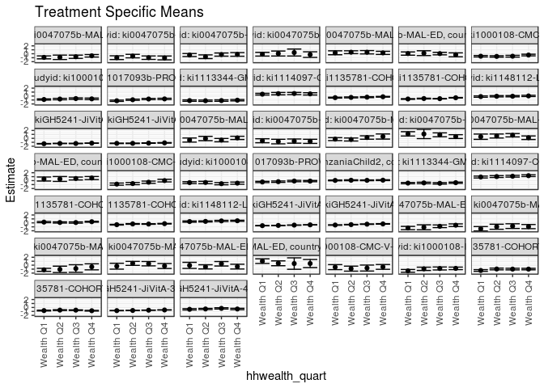

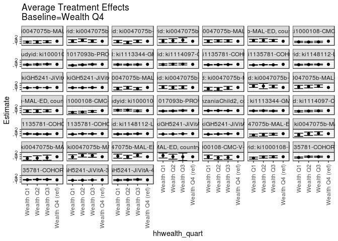

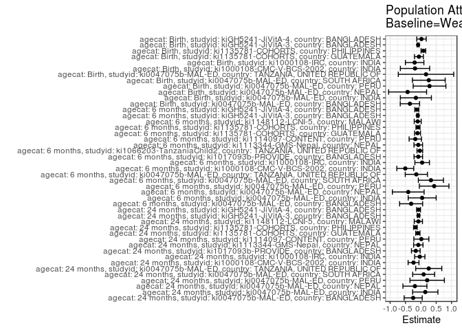

## Results Table

### Parameter: TSM

| agecat | studyid | country | intervention_level | baseline_level | estimate | ci_lower | ci_upper |
| --- | --- | --- | --- | --- | --- | --- | --- |
| Birth | ki0047075b-MAL-ED | BANGLADESH | Wealth Q4 | NA | -0.5852381 | -0.9155280 | -0.2549482 |
| Birth | ki0047075b-MAL-ED | BANGLADESH | Wealth Q1 | NA | -1.2994118 | -1.7134235 | -0.8854000 |
| Birth | ki0047075b-MAL-ED | BANGLADESH | Wealth Q2 | NA | -1.1105556 | -1.7339535 | -0.4871576 |
| Birth | ki0047075b-MAL-ED | BANGLADESH | Wealth Q3 | NA | -0.8590000 | -1.1946541 | -0.5233459 |
| Birth | ki0047075b-MAL-ED | INDIA | Wealth Q4 | NA | -0.9381818 | -1.4602711 | -0.4160926 |
| Birth | ki0047075b-MAL-ED | INDIA | Wealth Q1 | NA | -1.4947059 | -2.0549431 | -0.9344687 |
| Birth | ki0047075b-MAL-ED | INDIA | Wealth Q2 | NA | -0.9780000 | -1.6177530 | -0.3382470 |
| Birth | ki0047075b-MAL-ED | INDIA | Wealth Q3 | NA | -0.8145455 | -1.4092012 | -0.2198897 |
| Birth | ki0047075b-MAL-ED | NEPAL | Wealth Q4 | NA | -0.4188889 | -1.1801639 | 0.3423862 |
| Birth | ki0047075b-MAL-ED | NEPAL | Wealth Q1 | NA | -1.1812500 | -1.5597377 | -0.8027623 |
| Birth | ki0047075b-MAL-ED | NEPAL | Wealth Q2 | NA | -1.0533333 | -1.8600071 | -0.2466596 |
| Birth | ki0047075b-MAL-ED | NEPAL | Wealth Q3 | NA | -0.8500000 | -1.8133361 | 0.1133361 |
| Birth | ki0047075b-MAL-ED | PERU | Wealth Q4 | NA | -0.2070000 | -0.8370815 | 0.4230815 |
| Birth | ki0047075b-MAL-ED | PERU | Wealth Q1 | NA | -0.2566667 | -1.0027650 | 0.4894317 |
| Birth | ki0047075b-MAL-ED | PERU | Wealth Q2 | NA | 0.4544444 | -0.0496372 | 0.9585261 |
| Birth | ki0047075b-MAL-ED | PERU | Wealth Q3 | NA | 0.3812500 | -0.1703600 | 0.9328600 |
| Birth | ki0047075b-MAL-ED | SOUTH AFRICA | Wealth Q4 | NA | -0.3646667 | -0.9605402 | 0.2312068 |
| Birth | ki0047075b-MAL-ED | SOUTH AFRICA | Wealth Q1 | NA | -0.0531250 | -0.8245563 | 0.7183063 |
| Birth | ki0047075b-MAL-ED | SOUTH AFRICA | Wealth Q2 | NA | -0.4171429 | -0.9422000 | 0.1079143 |
| Birth | ki0047075b-MAL-ED | SOUTH AFRICA | Wealth Q3 | NA | 0.3606250 | -0.2056623 | 0.9269123 |
| Birth | ki0047075b-MAL-ED | TANZANIA, UNITED REPUBLIC OF | Wealth Q4 | NA | 0.4240000 | -0.6034412 | 1.4514412 |
| Birth | ki0047075b-MAL-ED | TANZANIA, UNITED REPUBLIC OF | Wealth Q1 | NA | 1.0250000 | 0.4445131 | 1.6054869 |
| Birth | ki0047075b-MAL-ED | TANZANIA, UNITED REPUBLIC OF | Wealth Q2 | NA | 0.4742857 | -0.1398244 | 1.0883959 |
| Birth | ki0047075b-MAL-ED | TANZANIA, UNITED REPUBLIC OF | Wealth Q3 | NA | 0.4100000 | -1.0412048 | 1.8612048 |
| Birth | ki1000108-CMC-V-BCS-2002 | INDIA | Wealth Q4 | NA | -0.4383871 | -1.0422176 | 0.1654435 |
| Birth | ki1000108-CMC-V-BCS-2002 | INDIA | Wealth Q1 | NA | -0.4950000 | -1.1313895 | 0.1413895 |
| Birth | ki1000108-CMC-V-BCS-2002 | INDIA | Wealth Q2 | NA | -0.8770000 | -1.5083693 | -0.2456307 |
| Birth | ki1000108-CMC-V-BCS-2002 | INDIA | Wealth Q3 | NA | -0.7260000 | -1.4786744 | 0.0266744 |
| Birth | ki1000108-IRC | INDIA | Wealth Q4 | NA | -0.8089873 | -1.1314135 | -0.4865611 |
| Birth | ki1000108-IRC | INDIA | Wealth Q1 | NA | -1.4476667 | -1.7995427 | -1.0957906 |

[output cut: 150 more lines]

### Parameter: E(Y)

| agecat | studyid | country | intervention_level | baseline_level | estimate | ci_lower | ci_upper |
| --- | --- | --- | --- | --- | --- | --- | --- |
| Birth | ki0047075b-MAL-ED | BANGLADESH | NA | NA | -0.9414474 | -1.1655223 | -0.7173724 |
| Birth | ki0047075b-MAL-ED | INDIA | NA | NA | -1.0992593 | -1.4060416 | -0.7924769 |
| Birth | ki0047075b-MAL-ED | NEPAL | NA | NA | -0.8496667 | -1.2385841 | -0.4607492 |
| Birth | ki0047075b-MAL-ED | PERU | NA | NA | 0.0766667 | -0.2519852 | 0.4053186 |
| Birth | ki0047075b-MAL-ED | SOUTH AFRICA | NA | NA | -0.1047541 | -0.4290621 | 0.2195539 |
| Birth | ki0047075b-MAL-ED | TANZANIA, UNITED REPUBLIC OF | NA | NA | 0.5930435 | 0.1251922 | 1.0608948 |
| Birth | ki1000108-CMC-V-BCS-2002 | INDIA | NA | NA | -0.6275000 | -0.9746292 | -0.2803708 |
| Birth | ki1000108-IRC | INDIA | NA | NA | -1.0105831 | -1.1973019 | -0.8238643 |
| Birth | ki1135781-COHORTS | GUATEMALA | NA | NA | -1.0572840 | -1.1606089 | -0.9539590 |
| Birth | ki1135781-COHORTS | PHILIPPINES | NA | NA | -0.7422912 | -0.7886598 | -0.6959226 |
| Birth | kiGH5241-JiVitA-3 | BANGLADESH | NA | NA | -0.7239386 | -0.7437757 | -0.7041015 |
| Birth | kiGH5241-JiVitA-4 | BANGLADESH | NA | NA | -0.3683163 | -0.4490504 | -0.2875821 |
| 6 months | ki0047075b-MAL-ED | BANGLADESH | NA | NA | -0.2054115 | -0.4495784 | 0.0387554 |
| 6 months | ki0047075b-MAL-ED | INDIA | NA | NA | -0.7227934 | -0.9900648 | -0.4555221 |
| 6 months | ki0047075b-MAL-ED | NEPAL | NA | NA | 0.0465079 | -0.2108391 | 0.3038550 |
| 6 months | ki0047075b-MAL-ED | PERU | NA | NA | 0.8727778 | 0.5137098 | 1.2318457 |
| 6 months | ki0047075b-MAL-ED | SOUTH AFRICA | NA | NA | 0.4787179 | 0.2126042 | 0.7448317 |
| 6 months | ki0047075b-MAL-ED | TANZANIA, UNITED REPUBLIC OF | NA | NA | 0.5033333 | 0.2619074 | 0.7447593 |
| 6 months | ki1000108-CMC-V-BCS-2002 | INDIA | NA | NA | -0.5026766 | -0.6536848 | -0.3516685 |
| 6 months | ki1000108-IRC | INDIA | NA | NA | -0.5989297 | -0.7344491 | -0.4634104 |
| 6 months | ki1017093b-PROVIDE | BANGLADESH | NA | NA | -0.2080201 | -0.2927357 | -0.1233045 |
| 6 months | ki1066203-TanzaniaChild2 | TANZANIA, UNITED REPUBLIC OF | NA | NA | 0.0801680 | 0.0273223 | 0.1330136 |
| 6 months | ki1113344-GMS-Nepal | NEPAL | NA | NA | -0.6047987 | -0.6909649 | -0.5186325 |
| 6 months | ki1114097-CONTENT | PERU | NA | NA | 1.0684318 | 0.9515274 | 1.1853362 |
| 6 months | ki1135781-COHORTS | GUATEMALA | NA | NA | 0.1914471 | 0.1185005 | 0.2643936 |
| 6 months | ki1135781-COHORTS | PHILIPPINES | NA | NA | -0.2938433 | -0.3352064 | -0.2524802 |
| 6 months | ki1148112-LCNI-5 | MALAWI | NA | NA | 0.4418137 | 0.3703100 | 0.5133174 |
| 6 months | kiGH5241-JiVitA-3 | BANGLADESH | NA | NA | -0.5932502 | -0.6127743 | -0.5737261 |
| 6 months | kiGH5241-JiVitA-4 | BANGLADESH | NA | NA | -0.3901595 | -0.4274150 | -0.3529041 |
| 24 months | ki0047075b-MAL-ED | BANGLADESH | NA | NA | -0.7648701 | -0.9729655 | -0.5567748 |
| 24 months | ki0047075b-MAL-ED | INDIA | NA | NA | -0.9125352 | -1.1472376 | -0.6778328 |
| 24 months | ki0047075b-MAL-ED | NEPAL | NA | NA | -0.3526190 | -0.5782459 | -0.1269921 |
| 24 months | ki0047075b-MAL-ED | PERU | NA | NA | -0.0095313 | -0.3657847 | 0.3467222 |
| 24 months | ki0047075b-MAL-ED | SOUTH AFRICA | NA | NA | 0.3131818 | 0.1018345 | 0.5245291 |
| 24 months | ki0047075b-MAL-ED | TANZANIA, UNITED REPUBLIC OF | NA | NA | -0.0049153 | -0.2462498 | 0.2364193 |
| 24 months | ki1000108-CMC-V-BCS-2002 | INDIA | NA | NA | -0.5571505 | -0.6585247 | -0.4557763 |
| 24 months | ki1000108-IRC | INDIA | NA | NA | -0.7458150 | -0.8368180 | -0.6548120 |
| 24 months | ki1017093b-PROVIDE | BANGLADESH | NA | NA | -0.8896187 | -0.9726240 | -0.8066134 |
| 24 months | ki1113344-GMS-Nepal | NEPAL | NA | NA | -1.1315863 | -1.2192240 | -1.0439487 |
| 24 months | ki1114097-CONTENT | PERU | NA | NA | 0.5668293 | 0.4302437 | 0.7034148 |
| 24 months | ki1135781-COHORTS | GUATEMALA | NA | NA | -0.2791396 | -0.3336899 | -0.2245893 |
| 24 months | ki1135781-COHORTS | PHILIPPINES | NA | NA | -0.6099592 | -0.6467541 | -0.5731643 |
| 24 months | ki1148112-LCNI-5 | MALAWI | NA | NA | -0.0478674 | -0.1301904 | 0.0344557 |
| 24 months | kiGH5241-JiVitA-3 | BANGLADESH | NA | NA | -1.2973086 | -1.3206115 | -1.2740057 |
| 24 months | kiGH5241-JiVitA-4 | BANGLADESH | NA | NA | -1.2231776 | -1.2550332 | -1.1913220 |

### Parameter: ATE

| agecat | studyid | country | intervention_level | baseline_level | estimate | ci_lower | ci_upper |
| --- | --- | --- | --- | --- | --- | --- | --- |
| Birth | ki0047075b-MAL-ED | BANGLADESH | Wealth Q4 | Wealth Q4 | 0.0000000 | 0.0000000 | 0.0000000 |
| Birth | ki0047075b-MAL-ED | BANGLADESH | Wealth Q1 | Wealth Q4 | -0.7141737 | -1.2437935 | -0.1845539 |
| Birth | ki0047075b-MAL-ED | BANGLADESH | Wealth Q2 | Wealth Q4 | -0.5253175 | -1.2308076 | 0.1801727 |
| Birth | ki0047075b-MAL-ED | BANGLADESH | Wealth Q3 | Wealth Q4 | -0.2737619 | -0.7446707 | 0.1971469 |
| Birth | ki0047075b-MAL-ED | INDIA | Wealth Q4 | Wealth Q4 | 0.0000000 | 0.0000000 | 0.0000000 |
| Birth | ki0047075b-MAL-ED | INDIA | Wealth Q1 | Wealth Q4 | -0.5565241 | -1.3223197 | 0.2092716 |
| Birth | ki0047075b-MAL-ED | INDIA | Wealth Q2 | Wealth Q4 | -0.0398182 | -0.8655670 | 0.7859306 |
| Birth | ki0047075b-MAL-ED | INDIA | Wealth Q3 | Wealth Q4 | 0.1236364 | -0.6676870 | 0.9149597 |
| Birth | ki0047075b-MAL-ED | NEPAL | Wealth Q4 | Wealth Q4 | 0.0000000 | 0.0000000 | 0.0000000 |
| Birth | ki0047075b-MAL-ED | NEPAL | Wealth Q1 | Wealth Q4 | -0.7623611 | -1.6125332 | 0.0878110 |
| Birth | ki0047075b-MAL-ED | NEPAL | Wealth Q2 | Wealth Q4 | -0.6344444 | -1.7436163 | 0.4747274 |
| Birth | ki0047075b-MAL-ED | NEPAL | Wealth Q3 | Wealth Q4 | -0.4311111 | -1.6589369 | 0.7967147 |
| Birth | ki0047075b-MAL-ED | PERU | Wealth Q4 | Wealth Q4 | 0.0000000 | 0.0000000 | 0.0000000 |
| Birth | ki0047075b-MAL-ED | PERU | Wealth Q1 | Wealth Q4 | -0.0496667 | -1.0262246 | 0.9268913 |
| Birth | ki0047075b-MAL-ED | PERU | Wealth Q2 | Wealth Q4 | 0.6614444 | -0.1454639 | 1.4683527 |
| Birth | ki0047075b-MAL-ED | PERU | Wealth Q3 | Wealth Q4 | 0.5882500 | -0.2491724 | 1.4256724 |
| Birth | ki0047075b-MAL-ED | SOUTH AFRICA | Wealth Q4 | Wealth Q4 | 0.0000000 | 0.0000000 | 0.0000000 |
| Birth | ki0047075b-MAL-ED | SOUTH AFRICA | Wealth Q1 | Wealth Q4 | 0.3115417 | -0.6632258 | 1.2863091 |
| Birth | ki0047075b-MAL-ED | SOUTH AFRICA | Wealth Q2 | Wealth Q4 | -0.0524762 | -0.8466740 | 0.7417217 |
| Birth | ki0047075b-MAL-ED | SOUTH AFRICA | Wealth Q3 | Wealth Q4 | 0.7252917 | -0.0967463 | 1.5473297 |
| Birth | ki0047075b-MAL-ED | TANZANIA, UNITED REPUBLIC OF | Wealth Q4 | Wealth Q4 | 0.0000000 | 0.0000000 | 0.0000000 |
| Birth | ki0047075b-MAL-ED | TANZANIA, UNITED REPUBLIC OF | Wealth Q1 | Wealth Q4 | 0.6010000 | -0.5790849 | 1.7810849 |
| Birth | ki0047075b-MAL-ED | TANZANIA, UNITED REPUBLIC OF | Wealth Q2 | Wealth Q4 | 0.0502857 | -1.1466966 | 1.2472680 |
| Birth | ki0047075b-MAL-ED | TANZANIA, UNITED REPUBLIC OF | Wealth Q3 | Wealth Q4 | -0.0140000 | -1.7920975 | 1.7640975 |
| Birth | ki1000108-CMC-V-BCS-2002 | INDIA | Wealth Q4 | Wealth Q4 | 0.0000000 | 0.0000000 | 0.0000000 |
| Birth | ki1000108-CMC-V-BCS-2002 | INDIA | Wealth Q1 | Wealth Q4 | -0.0566129 | -0.9338830 | 0.8206572 |
| Birth | ki1000108-CMC-V-BCS-2002 | INDIA | Wealth Q2 | Wealth Q4 | -0.4386129 | -1.3122482 | 0.4350224 |
| Birth | ki1000108-CMC-V-BCS-2002 | INDIA | Wealth Q3 | Wealth Q4 | -0.2876129 | -1.2525637 | 0.6773379 |
| Birth | ki1000108-IRC | INDIA | Wealth Q4 | Wealth Q4 | 0.0000000 | 0.0000000 | 0.0000000 |
| Birth | ki1000108-IRC | INDIA | Wealth Q1 | Wealth Q4 | -0.6386793 | -1.1159375 | -0.1614211 |

[output cut: 150 more lines]

### Parameter: PAR

| agecat | studyid | country | intervention_level | baseline_level | estimate | ci_lower | ci_upper |
| --- | --- | --- | --- | --- | --- | --- | --- |
| Birth | ki0047075b-MAL-ED | BANGLADESH | Wealth Q4 | NA | -0.3562093 | -0.6708736 | -0.0415450 |
| Birth | ki0047075b-MAL-ED | INDIA | Wealth Q4 | NA | -0.1610774 | -0.6666886 | 0.3445337 |
| Birth | ki0047075b-MAL-ED | NEPAL | Wealth Q4 | NA | -0.4307778 | -1.0497064 | 0.1881508 |
| Birth | ki0047075b-MAL-ED | PERU | Wealth Q4 | NA | 0.2836667 | -0.2496791 | 0.8170124 |
| Birth | ki0047075b-MAL-ED | SOUTH AFRICA | Wealth Q4 | NA | 0.2599126 | -0.2745205 | 0.7943456 |
| Birth | ki0047075b-MAL-ED | TANZANIA, UNITED REPUBLIC OF | Wealth Q4 | NA | 0.1690435 | -0.7340337 | 1.0721206 |
| Birth | ki1000108-CMC-V-BCS-2002 | INDIA | Wealth Q4 | NA | -0.1891129 | -0.6668417 | 0.2886159 |
| Birth | ki1000108-IRC | INDIA | Wealth Q4 | NA | -0.2015957 | -0.5031499 | 0.0999584 |
| Birth | ki1135781-COHORTS | GUATEMALA | Wealth Q4 | NA | -0.0621289 | -0.2065173 | 0.0822595 |
| Birth | ki1135781-COHORTS | PHILIPPINES | Wealth Q4 | NA | 0.0835493 | 0.0081632 | 0.1589353 |
| Birth | kiGH5241-JiVitA-3 | BANGLADESH | Wealth Q4 | NA | -0.0894265 | -0.1214488 | -0.0574043 |
| Birth | kiGH5241-JiVitA-4 | BANGLADESH | Wealth Q4 | NA | 0.0210955 | -0.1330408 | 0.1752319 |
| 6 months | ki0047075b-MAL-ED | BANGLADESH | Wealth Q4 | NA | -0.3161258 | -0.6914193 | 0.0591677 |
| 6 months | ki0047075b-MAL-ED | INDIA | Wealth Q4 | NA | 0.0440584 | -0.4124192 | 0.5005360 |
| 6 months | ki0047075b-MAL-ED | NEPAL | Wealth Q4 | NA | -0.4098557 | -0.9271805 | 0.1074691 |
| 6 months | ki0047075b-MAL-ED | PERU | Wealth Q4 | NA | 0.4342778 | -0.0477590 | 0.9163146 |
| 6 months | ki0047075b-MAL-ED | SOUTH AFRICA | Wealth Q4 | NA | 0.3290121 | -0.0806864 | 0.7387105 |
| 6 months | ki0047075b-MAL-ED | TANZANIA, UNITED REPUBLIC OF | Wealth Q4 | NA | -0.1468889 | -0.5085120 | 0.2147342 |
| 6 months | ki1000108-CMC-V-BCS-2002 | INDIA | Wealth Q4 | NA | -0.5071503 | -0.7832770 | -0.2310236 |
| 6 months | ki1000108-IRC | INDIA | Wealth Q4 | NA | 0.0436203 | -0.1938960 | 0.2811365 |
| 6 months | ki1017093b-PROVIDE | BANGLADESH | Wealth Q4 | NA | -0.0816975 | -0.2206970 | 0.0573019 |
| 6 months | ki1066203-TanzaniaChild2 | TANZANIA, UNITED REPUBLIC OF | Wealth Q4 | NA | -0.0324301 | -0.1244301 | 0.0595698 |
| 6 months | ki1113344-GMS-Nepal | NEPAL | Wealth Q4 | NA | -0.0829902 | -0.2230285 | 0.0570481 |
| 6 months | ki1114097-CONTENT | PERU | Wealth Q4 | NA | -0.1803342 | -0.3815475 | 0.0208790 |
| 6 months | ki1135781-COHORTS | GUATEMALA | Wealth Q4 | NA | -0.1067535 | -0.2023421 | -0.0111649 |
| 6 months | ki1135781-COHORTS | PHILIPPINES | Wealth Q4 | NA | -0.0930369 | -0.1585540 | -0.0275197 |
| 6 months | ki1148112-LCNI-5 | MALAWI | Wealth Q4 | NA | -0.1009052 | -0.2145548 | 0.0127444 |
| 6 months | kiGH5241-JiVitA-3 | BANGLADESH | Wealth Q4 | NA | -0.0988230 | -0.1268986 | -0.0707474 |
| 6 months | kiGH5241-JiVitA-4 | BANGLADESH | Wealth Q4 | NA | -0.1307604 | -0.1962620 | -0.0652588 |
| 24 months | ki0047075b-MAL-ED | BANGLADESH | Wealth Q4 | NA | -0.2493939 | -0.5448687 | 0.0460808 |
| 24 months | ki0047075b-MAL-ED | INDIA | Wealth Q4 | NA | 0.1446870 | -0.2674636 | 0.5568376 |
| 24 months | ki0047075b-MAL-ED | NEPAL | Wealth Q4 | NA | -0.1930736 | -0.5838568 | 0.1977096 |
| 24 months | ki0047075b-MAL-ED | PERU | Wealth Q4 | NA | 0.2069687 | -0.3537686 | 0.7677061 |
| 24 months | ki0047075b-MAL-ED | SOUTH AFRICA | Wealth Q4 | NA | 0.0916193 | -0.2649653 | 0.4482039 |
| 24 months | ki0047075b-MAL-ED | TANZANIA, UNITED REPUBLIC OF | Wealth Q4 | NA | 0.2580847 | -0.1672317 | 0.6834012 |
| 24 months | ki1000108-CMC-V-BCS-2002 | INDIA | Wealth Q4 | NA | -0.2373962 | -0.4145641 | -0.0602282 |
| 24 months | ki1000108-IRC | INDIA | Wealth Q4 | NA | -0.0336483 | -0.2007385 | 0.1334418 |
| 24 months | ki1017093b-PROVIDE | BANGLADESH | Wealth Q4 | NA | -0.1642341 | -0.3052406 | -0.0232276 |
| 24 months | ki1113344-GMS-Nepal | NEPAL | Wealth Q4 | NA | -0.0816388 | -0.2340570 | 0.0707793 |
| 24 months | ki1114097-CONTENT | PERU | Wealth Q4 | NA | 0.0171951 | -0.2272798 | 0.2616700 |
| 24 months | ki1135781-COHORTS | GUATEMALA | Wealth Q4 | NA | -0.0977075 | -0.1666807 | -0.0287343 |
| 24 months | ki1135781-COHORTS | PHILIPPINES | Wealth Q4 | NA | -0.1772146 | -0.2356263 | -0.1188030 |
| 24 months | ki1148112-LCNI-5 | MALAWI | Wealth Q4 | NA | -0.0801254 | -0.2137537 | 0.0535028 |
| 24 months | kiGH5241-JiVitA-3 | BANGLADESH | Wealth Q4 | NA | -0.0765230 | -0.1136168 | -0.0394292 |
| 24 months | kiGH5241-JiVitA-4 | BANGLADESH | Wealth Q4 | NA | -0.0740307 | -0.1369416 | -0.0111198 |